# Replication of “How Will I Be Remembered? Conserving the Environment for the Sake of One’s Legacy” by Zaval, Markowitz & Weber (2015, Psychological Science)

## Introduction

Although encouraging pro-environmental behaviors is extremely important to the future, there are a number of psychological barriers that can prevent pro-environmental behaviors. Specifically, the long time horizon and psychological distance serve as barriers to this important goal. The current paper looks to leverage these elements of pro-environmental behavior into opportunities, rather than barriers.

Specifically, the paper finds that priming legacy motives increased donations to an environmental charity, proenvironmental intentions, and climate change beliefs. To prime legacy motives, participants write about what they want to be remembered for by future generations. This increases motivation to leave a positive legacy, which in turn increases pro-environmental behaviors. Therefore, this paper uses a simple intervention to leverage a major barrier in environmental behavior (future-focused and distant) into an opportunity to encourage these behaviors.

## Methods

### Link to Experiment

The control condition is available online at: http://stanford.edu/~rhiac/Psych254/legacy_proj_control.html

The experimental (prime) condition is available online at: http://stanford.edu/~rhiac/Psych254/legacy_proj_prime.html

### Link to original study supplements

All of the supplements for the original study (including both survey questions and data) are available at: https://dataverse.harvard.edu/dataset.xhtml?persistentId=doi:10.7910/DVN/27740&studyListingIndex=3_81dd3734f5b119094c28f53886bc

### Power Analysis

The original study reports cohen’s d’s ranging from 0.23 to 0.36 on the various measures used (legacy motives, climate change beliefs, behavioral intentions, and donation measure). Therefore, I’ve run power analysis on one of the key effects, the effect of condition on behavioral intentions (d=0.36)

```r
power.t.test(delta=0.36, power=.80, sig.level=0.05)
```

```
##
##      Two-sample t test power calculation
##
##               n = 122.0925
##           delta = 0.36
##              sd = 1
##       sig.level = 0.05
##           power = 0.8
##     alternative = two.sided
##
## NOTE: n is number in *each* group
```

Obviously a larger sample is required for adequate power to detect the smaller effects.

### Planned Sample

The original paper uses a sample size of 312 participants, based on the estimated effect size from a pilot test conducted by the original authors indicating a small to medium effect size. This is the most feasible number of participants that will not severely underpower the study. I will be adding an additional 5% for a total of 328 participants, to account for any possible exclusions. Given a sample of 312 participants, the project has 80% power to detect an effect size larger than d=0.31 (which includes the key effect being examined in the replication).

### Materials & Procedure

**Writing activity** Participants will be assigned to one of two conditions. The two conditions will be posted as two sepatate MTurk HITs, given the different amounts of compensation required (due to additional time spent writing). As per the original experiment, “In the legacy condition, participants began by writing a short essay describing what they want to be remembered for by future generations…The essay-writing task was omitted in the control condition, which otherwise followed the same procedure as the legacy condition.” The writing task will be copied verbatim from the project’s supplemental materials online.

Like the original study, a time minimum will be imposed on participants. In the current study, participants will need to wait 4 minutes before being allowed to advance to the next page. In addition, participants will be required to write a minimum of 20 words (approximately 2-3 sentences) before advancing.

**Environmental Behaviors** As per the original experiment, “Participants next answered two sets of questions, one assessing their beliefs about climate change and the other their willingness to take proenvironmental action. Climate-change beliefs were measured using the average score of four randomly ordered items (…e.g., “I feel a responsibility to reduce my personal contribution to climate change”). Participants responded to each statement on a 7-point scale ranging from 1 (strongly disagree) to 7 (strongly agree). Similarly, proenvironmental behavioral intentions were measured using the average score of six items that asked participants how often they intend to perform actions to help mitigate climate change over the next month (…e.g., “Buy green products instead of regular products”); responses were made on a scale from 1 (never) to 6 (all the time).”

All participants completed the behavioral intentions questions first, then the climate change beliefs questions. This is because for the purposes of replication, we are focusing on the biggest effect in the original study, behavioral intentions, as our key effect (but will also try to replicate the environmental attitudes finding as well).

**Manipulation Check/Mediator - Legacy Motives** Following the original experiment, “This measure consisted of the average score of three items relating to legacy motives…: (a) “It is important to me to leave a positive legacy,” (b) “It is important for me to leave a positive mark on society,” and (c) “I care about what future generations think of me.” Participants indicated the extent to which each statement described them on a scale from 1 (not at all) to 6 (a great amount). This legacy-motives scale was placed at the end of the survey…” This section also included a number of general prosociality items, which were not expected to mediate the effect of legacy motives on environmental behaviors and attitudes, and are not included in analysis, as per the original paper.

### Analysis Plan

As per the original paper, no participants will be excluded from analysis, except for participants who took the survey more than once (in which case only the first instance will be counted). In addition, although additional analysis was performed controlling for a range of demographic variables (to show the robustness of the finding), the original analysis examines the effect of condition on the various DV’s, without controlling for demographic variables.

Linear regressions will be performed to examine the effect of the legacy prime on legacy motives, climate change beliefs, and behavioral intentions.

In addition, mediation analysis will be conducted using both a sobel’s z test, and using bootstrapping as suggested by Preacher & Hayes, 2008, with 5,000 samples. Specifically, it is predicted that legacy motives mediates the relationship between condition (legacy prime/no legacy prime) and both climate change attitudes and intentions.

### Differences from Original Study

In the original study, all participants were paid the same amount. However, in this study, we will use two separate MTurk HITs, one which pays $0.20 (control) and one that pays $0.60 (legacy prime).

In addition, in the original study the average time taken to write the essay was 6.5 minutes. However, we will be shortening the essay writing task to 4 minutes instead. This 4 minute minimum was enforced by not allowing participants to advance to the next page until 4 minutes had elapsed. In addition, a 20 word minumum was imposed on the essay task before submission was allowed. There was no countdown indicator, but participants were asked to write more if they tried to submit an essay with under 20 words.

Finally, in the original study, an additional DV was included, donation to an environmental charity. Given that this DV shows the same trend as the other DV’s being measured, this DV will be excluded from the present replication.

## (Post Data Collection) Methods Addendum

### Actual Sample

The current study included a sample of 328 participants collected on Amazon MTurk. Seven participants completed both conditions, therefore, the latter of their observations (control) was excluded from analysis. Therefore, this left 321 participants (132 female, 185 male, 4 other/prefer not to say, Mean age = 34).

### Differences from pre-data collection methods plan

The analysis follows the original pre-data collection methods plan, with some minor coding changes.

## Results

### Data preparation

Read in the data from .json files, and format into a dataframe.

```r
path <- "~/Desktop/2016_Winter/Stats_254/Project/rhiacProject/replication_report/"
files <- dir(paste0(path,"production-results"),
             pattern = "*.json")
d.raw <- data.frame(stringsAsFactors = FALSE)

for (f in files) {
jf <- paste0(path, "/production-results/", f)
jd <- fromJSON(file=jf)

#get rid of all of the instruction trials, which are labeled with 0
cols <- which(jd$answers$data$trial_number_block != 0)

#This code formats everything into a useable dataframe, and accounts for missing values by turning them into NA's
df <- jd$answers$data

id <- data.frame(workerid = jd$WorkerId,
                totalTime = df$totalTime,
                totalHiddenTime = ifelse(is.null(unlist(df$totalHiddenTime)),NA,
                         unlist(df$totalHiddenTime)),
                condition = df$condition,
                trialNum = df$trial_number_block[cols],
                trialType = df$trial_type[cols],
                sentence = df$sentence[cols],
                rating = df$rating,
                environmentalist =
                  ifelse(is.null(unlist(df$environmentalist)), NA,
                         unlist(df$environmentalist)),
                legacy_essay = df$legacy_essay,
                sex =
                  ifelse(is.null(unlist(df$sex)), NA,
                         unlist(df$sex)),
                race =
                  ifelse(is.null(unlist(df$race)), NA,
                         unlist(df$race)),
                year = df$year,
                english =
                  ifelse(is.null(unlist(df$english)),NA,
                         unlist(df$english)),
                grandparent =
                  ifelse(is.null(unlist(df$grandparent)),NA,
                         unlist(df$grandparent)),
                children =
                  ifelse(is.null(unlist(df$children)),NA,
                         unlist(df$children)),
                stringsAsFactors=FALSE)

d.raw <- bind_rows(d.raw, id)
}

#remove "filler"" questions
fillers <- c("I am well liked by my friends",
            "I feel a connection to future generations",
            "I feel a sense of responsibility to future generations",
            "I have important skills I can pass along to others",
            "Others would say I have made unique contributions to my community or society")
d.raw <- d.raw %>% filter(!sentence %in% fillers)

# Check number of participants to ensure no repeats
n = length(unique(d.raw$workerid))
```

```r
#some people took the survey twice. exclude as per data analysis plan. Everyone took the control survey second, therefore, exclude the latter observation

doubles <- d.raw %>% group_by(workerid, condition) %>%
  summarize(sum(condition))
duplicates <- names(which(table(doubles$workerid) > 1))

d.raw <- filter(d.raw, !(workerid %in% duplicates & condition == 0  ))

n = length(unique(d.raw$workerid))
```

The 3 DV’s are ratings on the behavioral intentions trials, ratings on the environmental attitudes trials, and ratings on the legacy motives trials. The indexes for each are computed as the average of the ratings for the items that make up the composite index.

```r
trial_index <- d.raw %>%
 group_by(workerid, trialType) %>%
 summarize("index"=mean(as.numeric(rating)), "condition" = condition[1], "year"=year[1], "sex"=sex[1], "environmentalist" = environmentalist[1], "race" = race[1], "year" = year[1], "grandparent" = grandparent[1], "children" = children[1], leg_essay=legacy_essay[1])

d <- spread(trial_index, trialType, index)
d <- d %>%
  rename(beh_int_index = beh_int_trial,
         env_att_index = env_att,
         leg_mot_index = legacy_motives2)

#Also correctly factor/numeric variables as appropriate
d$condition <- factor(d$condition, levels = c(0, 1), labels = c("control", "leg_prime"))
d$sex <- as.factor(d$sex)
d$environmentalist <- as.factor(d$environmentalist)
d$race <- as.factor(d$race)
d$grandparent <- as.factor(d$grandparent)
d$children <- as.factor(x = d$children)
d$year <- as.numeric(d$year)
```

### Confirmatory analysis

**Histograms of data distribution**

Histograms of our 3 index DV’s by condition

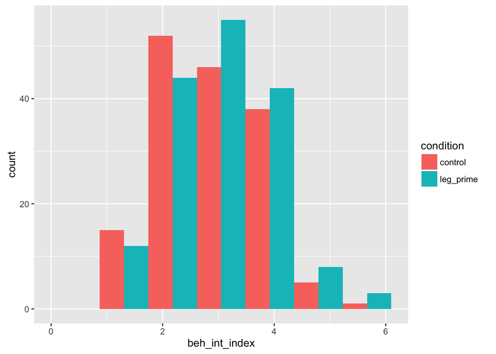

```r
#added .1 so values at the max of scale show
ggplot(d, aes(x=beh_int_index, fill=condition)) +
    geom_histogram(position="dodge", bins=7) +
    xlim(0, 6.1)
```

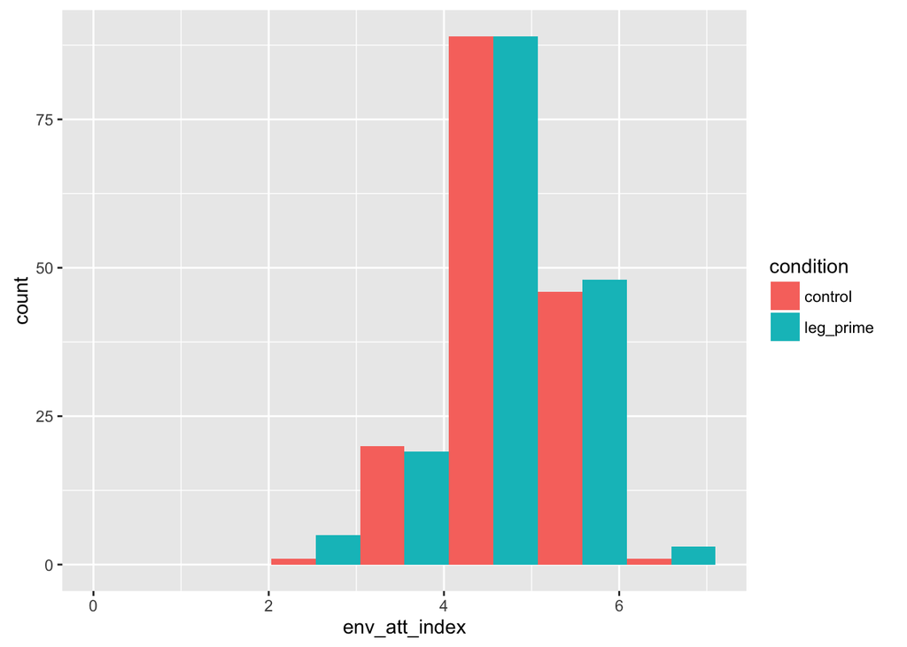

```r
ggplot(d, aes(x=env_att_index, fill=condition)) +
    geom_histogram(position="dodge", bins=7) +
    xlim(0, 7.1)
```

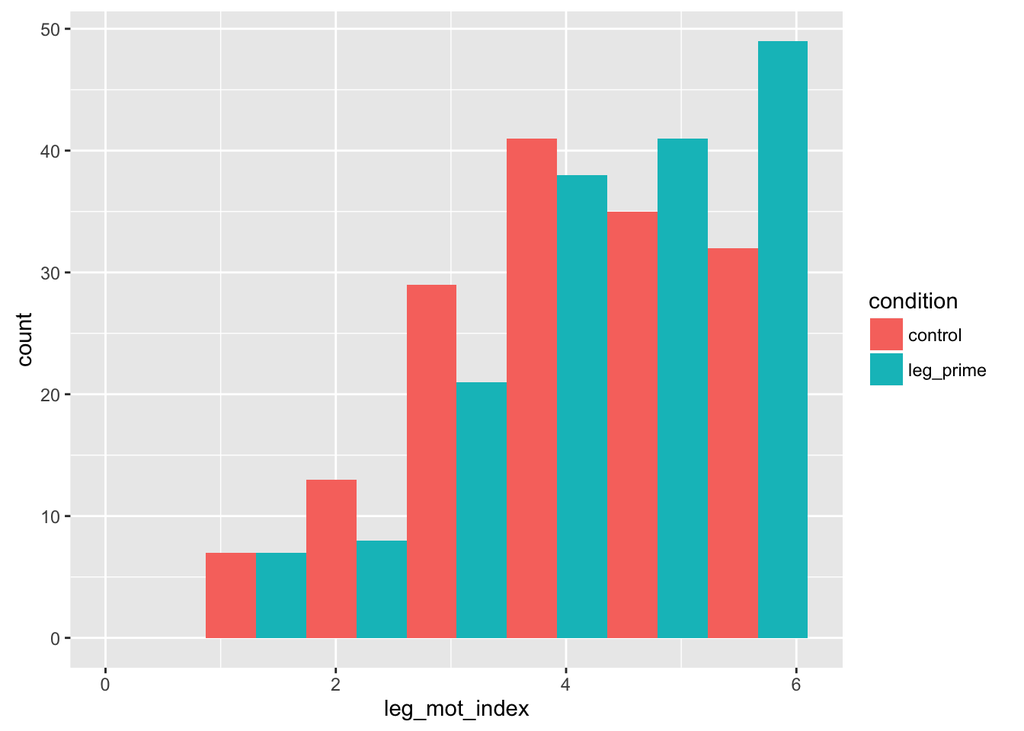

```r
ggplot(d, aes(x=leg_mot_index, fill=condition)) +
    geom_histogram(position="dodge", bins=7) +
    xlim(0, 6.1)
```

Legacy Motives as a Predictor of Behavioral Intentions

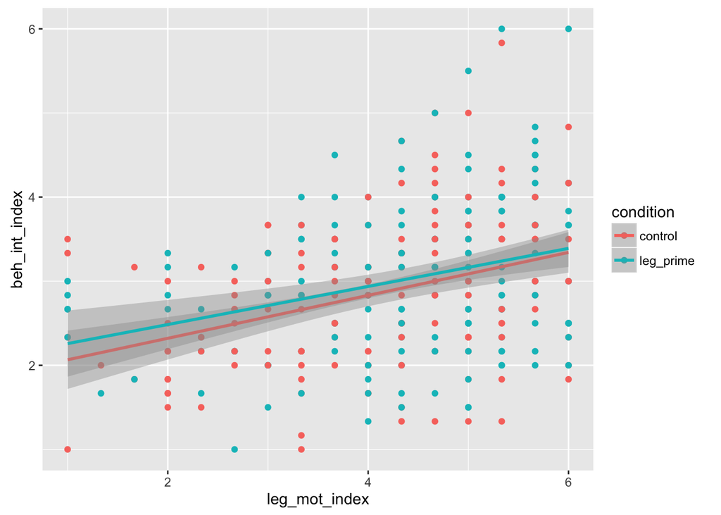

```r
ggplot(d) +
   geom_point(aes(x=leg_mot_index, y=beh_int_index, color=condition)) +
   geom_smooth(method = lm, aes(x=leg_mot_index, y=beh_int_index, color=condition))
```

Legacy Motives as a Predictor of Environmental Attitudes

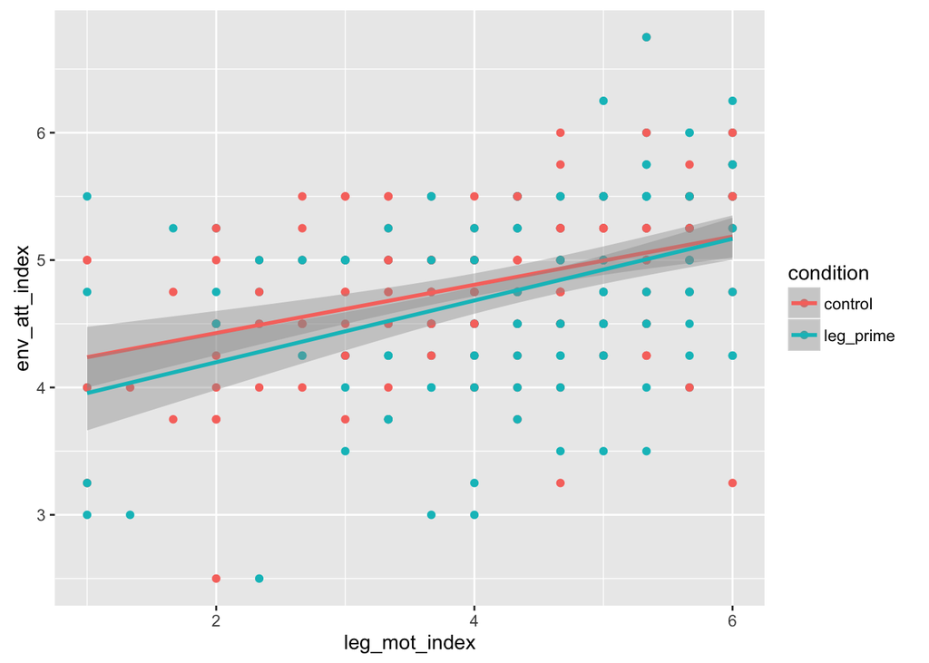

```r
ggplot(d) +
   geom_point(aes(x=leg_mot_index, y=env_att_index, color=condition)) +
   geom_smooth(method = lm, aes(x=leg_mot_index, y=env_att_index, color=condition))
```

**Figures of interest**

Replication of Figure 2a: Mean behavioral intention score by condition

Figure 2a:

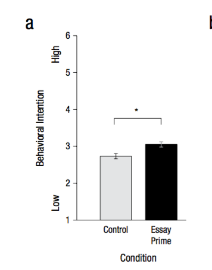

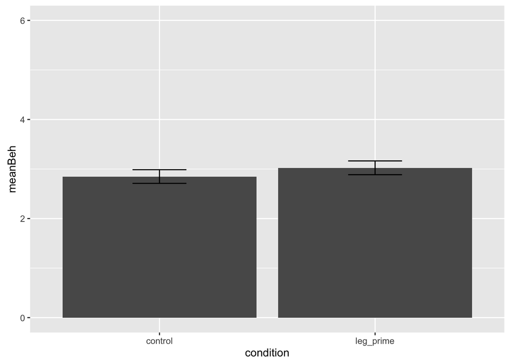

```r
ms_beh <- d %>%
  group_by(condition) %>%
  summarise(meanBeh = mean(beh_int_index, na.rm = TRUE),
            sem = sd(beh_int_index) / sqrt(n()),
            ci95 = 1.96*sem)

ggplot(ms_beh, aes(x=condition, y=meanBeh)) +
  geom_bar(stat = "identity") +
  ylim(0, 6) +
  geom_errorbar(aes(ymin = meanBeh - ci95,
                     ymax = meanBeh + ci95), width=0.25)
```

Mean behavioral attitudes score by condition

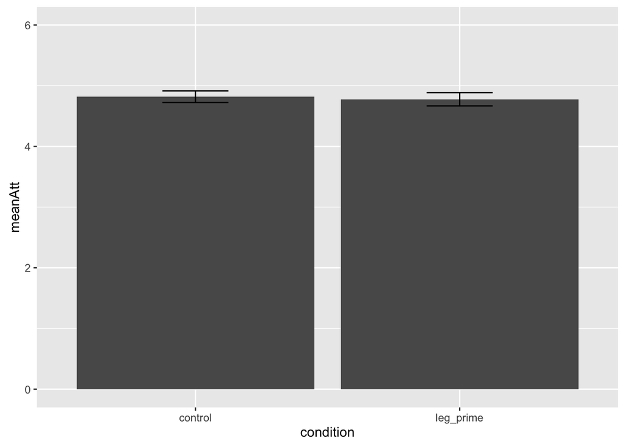

```r
ms_att <- d %>%
  group_by(condition) %>%
   summarise(meanAtt = mean(env_att_index, na.rm = TRUE),
            sem = sd(env_att_index) / sqrt(n()),
            ci95 = 1.96*sem)

ggplot(ms_att, aes(x=condition, y=meanAtt)) +
  geom_bar(stat = "identity") +
  ylim(0, 6) +
  geom_errorbar(aes(ymin = meanAtt - ci95,
                     ymax = meanAtt + ci95), width=0.25)
```

**Key Effects from Paper**

Effect of legacy prime on legacy motives

The original paper reports that, “As expected, the essay manipulation successfully enhanced overall legacy motives. Almost 10 min after being exposed to the manipulation, participants who wrote the essay reported higher legacy motives (M = 4.47, SD = 1.06), compared with those in the control condition (M = 4.19, SD = 1.05), F(1, 310) = 5.64, p = .018, Cohen’s d = 0.27.”

```r
model <- lm(leg_mot_index ~ condition, d)
kable(tidy(model))
```

| term | estimate | std.error | statistic | p.value |
| --- | --- | --- | --- | --- |
| (Intercept) | 4.0658174 | 0.0987565 | 41.170116 | 0.0000000 |
| conditionleg_prime | 0.3183289 | 0.1381645 | 2.303986 | 0.0218658 |

Effect of legacy prime on environmental behavior intentions

The original paper reports: “We also found a significant effect of the legacy prime on behavioral intentions. Participants who were primed reported greater behavioral intentions (M = 3.05, SD = 0.86) than those who were not primed (M=2.73,SD=0.85), F(1,309)=10.07, p=.002, d=0.36.”

```r
model <- lm(beh_int_index ~ condition, d)
kable(tidy(model))
```

| term | estimate | std.error | statistic | p.value |
| --- | --- | --- | --- | --- |
| (Intercept) | 2.8481953 | 0.0715074 | 39.830765 | 0.0000000 |
| conditionleg_prime | 0.1761949 | 0.1000419 | 1.761212 | 0.0791605 |

Effect of legacy prime on beliefs/attitudes

The original paper reports: “Moreover, as predicted, we found a significant effect of the legacy prime on willingness to engage in behaviors aimed at combating climate change. Participants who were primed with legacy motives had higher belief scores (M = 5.39, SD = 1.08) than those in the control condition (M = 5.11, SD = 1.27), F(1, 309) = 4.08, p = .040, d = 0.23.”

```r
model <- lm(env_att_index ~ condition, d)
kable(tidy(model))
```

| term | estimate | std.error | statistic | p.value |
| --- | --- | --- | --- | --- |
| (Intercept) | 4.8184713 | 0.0529945 | 90.9240389 | 0.0000000 |
| conditionleg_prime | -0.0425567 | 0.0741415 | -0.5739933 | 0.5663768 |

**Mediation Analysis**

**Path 1: Prime -> Legacy Motives -> Attitudes**

The original paper reports: “To confirm that the influence of the legacy prime on climate-change attitudes was driven by increases in legacy motives, we conducted a mediation analysis using the mean legacy-motives score as a mediator. The effect of the legacy prime on individuals’ climate-change beliefs was fully mediated by increases in legacy motives—direct effect of the priming condition on beliefs: t(308) = 2.01; effect of priming condition on beliefs, mediated by legacy motives: t(308) = 1.29, Sobel’s z = 2.19, p = .028. Mediation was also confirmed by a bias-corrected bootstrapping procedure using 5,000 samples (Preacher & Hayes, 2008; see Median Test in the Supplemental Material). This analysis showed that the indirect effect of the legacy prime on climate-change beliefs through legacy motives was significant, with a 95% confidence interval (CI) that excluded zero (β = 0.041, 95% CI = [0.01, 0.09], p = .029).”

Sobel

```r
sobel = sobel(d$condition, d$leg_mot_index, d$env_att_index)
sobel_chart <- sob_print(sobel)
kable(sobel_chart$Models)
```

|  | Estimate | Std. Error | t value | Pr(>\|t\|) |
| --- | --- | --- | --- | --- |
| Mod1: Y~X | 4.8184713 | 0.0529945 | 90.9240389 | 0.0000000 |
| predleg_prime | -0.0425567 | 0.0741415 | -0.5739933 | 0.5663768 |
| Mod2: Y~X+M | 3.9396648 | 0.1220686 | 32.2741914 | 0.0000000 |
| predleg_prime | -0.1113619 | 0.0685309 | -1.6249898 | 0.1051554 |
| med | 0.2161451 | 0.0275430 | 7.8475607 | 0.0000000 |
| Mod3: M~X | 4.0658174 | 0.0987565 | 41.1701162 | 0.0000000 |
| predleg_prime | 0.3183289 | 0.1381645 | 2.3039855 | 0.0218658 |

```r
kable(sobel_chart$Vals)
```

| IndirectEffect | SE | Z | N |
| --- | --- | --- | --- |
| 0.0688052 | 0.031124 | 2.210678 | 321 |

Bootstrapping

```r
mediation(x = as.numeric(d$condition),
          mediator = d$leg_mot_index,
          dv = d$env_att_index,
          conf.level=.95, bootstrap=TRUE, B=5000)
```

```
## [1] "Bootstrap resampling has begun. This process may take a considerable amount of time if the number of replications is large, which is optimal for the bootstrap procedure."
```

```
## $Y.on.X
## $Y.on.X$Regression.Table
##                 Estimate Std. Error    t value       p(>|t|)
## Intercept.Y_X  4.8610280 0.11799237 41.1978182 9.253021e-130
## c (Regressor) -0.0425567 0.07414146 -0.5739933  5.663768e-01
##               Low Conf Limit Up Conf Limit
## Intercept.Y_X      4.6288865     5.0931696
## c (Regressor)     -0.1884247     0.1033113
##
## $Y.on.X$Model.Fit
##        Residual standard error (RMSE) numerator df denomenator df
## Values                      0.6640188            1            319
##        F-Statistic p-value (F)        R^2      Adj R^2 Low Conf Limit
## Values   0.3294683   0.5663768 0.00103175 -0.002099811              0
##        Up Conf Limit
## Values    0.01958562
##
##
## $M.on.X
## $M.on.X$Regression.Table
##                Estimate Std. Error   t value      p(>|t|) Low Conf Limit
## Intercept.M_X 3.7474885  0.2198817 17.043202 9.200076e-47     3.31488694
## a (Regressor) 0.3183289  0.1381645  2.303985 2.186580e-02     0.04650023
##               Up Conf Limit
## Intercept.M_X     4.1800900
## a (Regressor)     0.5901576
##
## $M.on.X$Model.Fit
##        Residual standard error (RMSE) numerator df denomenator df
## Values                       1.237416            1            319
##        F-Statistic p-value (F)        R^2    Adj R^2 Low Conf Limit
## Values    5.308349   0.0218658 0.01636822 0.01328473   0.0001478656
##        Up Conf Limit
## Values    0.05465787
##
##
## $Y.on.X.and.M
## $Y.on.X.and.M$Regression.Table
##                       Estimate Std. Error   t value      p(>|t|)
## Intercept.Y_XM       4.0510268 0.14951207 27.094981 1.271450e-84
```

[output cut: 77 more lines]

```
##                                                       CI.Upper_BCa
## Indirect.Effect                                        0.139496338
## Indirect.Effect.Partially.Standardized                 0.205566444
## Index.of.Mediation                                     0.102868577
## R2_4.5                                                 0.002831414
## R2_4.6                                                 0.010095959
## R2_4.7                                                 0.053281872
## Maximum.Possible.Mediation.Effect                      1.339880997
## ab.to.Maximum.Possible.Mediation.Effect_kappa.squared  0.112949505
## Ratio.of.Indirect.to.Total.Effect                     -0.160459802
## Ratio.of.Indirect.to.Direct.Effect                     0.965118153
## Success.of.Surrogate.Endpoint                          0.316124072
## Residual.Based_Gamma                                   0.030108375
## Residual.Based.Standardized_gamma                      0.024755633
## SOS                                                   -0.269554544
```

**Path 2: Prime -> Legacy Motives -> Behavioral Intentions**

The original paper reports: “When we replaced climate-change attitudes with behavioral intentions as the outcome variable, behavioral intentions were also partially mediated by increases in legacy motives—direct effect of priming condition on intentions: t(311) = 3.17, effect of priming condition on beliefs, mediated by leg- acy motives: t(311) = 2.65, Sobel’s z = 2.11, p = .034; the indirect effect was significant (β = 0.034, 95% CI = [0.01, 0.08], p = .035).”

Sobel

```r
sobel = sobel(d$condition, d$leg_mot_index, d$beh_int_index)
sobel_chart <- sob_print(sobel)
kable(sobel_chart$Models)
```

|  | Estimate | Std. Error | t value | Pr(>\|t\|) |
| --- | --- | --- | --- | --- |
| Mod1: Y~X | 2.8481953 | 0.0715074 | 39.830765 | 0.0000000 |
| predleg_prime | 0.1761949 | 0.1000419 | 1.761212 | 0.0791605 |
| Mod2: Y~X+M | 1.8694097 | 0.1697184 | 11.014775 | 0.0000000 |
| predleg_prime | 0.0995619 | 0.0952821 | 1.044918 | 0.2968546 |
| med | 0.2407353 | 0.0382944 | 6.286429 | 0.0000000 |
| Mod3: M~X | 4.0658174 | 0.0987565 | 41.170116 | 0.0000000 |
| predleg_prime | 0.3183289 | 0.1381645 | 2.303986 | 0.0218658 |

```r
kable(sobel_chart$Vals)
```

| IndirectEffect | SE | Z | N |
| --- | --- | --- | --- |
| 0.076633 | 0.0354246 | 2.163273 | 321 |

Bootstrapping

```r
mediation(x = as.numeric(d$condition),
          mediator = d$leg_mot_index,
          dv = d$beh_int_index,
          conf.level=.95, bootstrap=TRUE, B=5000)
```

```
## [1] "Bootstrap resampling has begun. This process may take a considerable amount of time if the number of replications is large, which is optimal for the bootstrap procedure."
```

```
## $Y.on.X
## $Y.on.X$Regression.Table
##                Estimate Std. Error   t value      p(>|t|) Low Conf Limit
## Intercept.Y_X 2.6720004  0.1592115 16.782708 9.463526e-46     2.35876316
## c (Regressor) 0.1761949  0.1000419  1.761212 7.916052e-02    -0.02063026
##               Up Conf Limit
## Intercept.Y_X     2.9852377
## c (Regressor)     0.3730201
##
## $Y.on.X$Model.Fit
##        Residual standard error (RMSE) numerator df denomenator df
## Values                      0.8959854            1            319
##        F-Statistic p-value (F)         R^2     Adj R^2 Low Conf Limit
## Values    3.101868  0.07916052 0.009630084 0.006525476              0
##        Up Conf Limit
## Values     0.0420694
##
##
## $M.on.X
## $M.on.X$Regression.Table
##                Estimate Std. Error   t value      p(>|t|) Low Conf Limit
## Intercept.M_X 3.7474885  0.2198817 17.043202 9.200076e-47     3.31488694
## a (Regressor) 0.3183289  0.1381645  2.303985 2.186580e-02     0.04650023
##               Up Conf Limit
## Intercept.M_X     4.1800900
## a (Regressor)     0.5901576
##
## $M.on.X$Model.Fit
##        Residual standard error (RMSE) numerator df denomenator df
## Values                       1.237416            1            319
##        F-Statistic p-value (F)        R^2    Adj R^2 Low Conf Limit
## Values    5.308349   0.0218658 0.01636822 0.01328473   0.0001478656
##        Up Conf Limit
## Values    0.05465787
##
##
## $Y.on.X.and.M
## $Y.on.X.and.M$Regression.Table
##                       Estimate Std. Error  t value      p(>|t|)
## Intercept.Y_XM      1.76984781 0.20787450 8.514021 6.768350e-16
```

[output cut: 77 more lines]

```
##                                                       CI.Upper_BCa
## Indirect.Effect                                        0.156444421
## Indirect.Effect.Partially.Standardized                 0.169849102
## Index.of.Mediation                                     0.085120079
## R2_4.5                                                 0.023489974
## R2_4.6                                                 0.007015758
## R2_4.7                                                 0.050314543
## Maximum.Possible.Mediation.Effect                      1.904457135
## ab.to.Maximum.Possible.Mediation.Effect_kappa.squared  0.086881094
## Ratio.of.Indirect.to.Total.Effect                      3.712921957
## Ratio.of.Indirect.to.Direct.Effect                    46.666278736
## Success.of.Surrogate.Endpoint                          2.122205047
## Residual.Based_Gamma                                   0.032680525
## Residual.Based.Standardized_gamma                      0.030873462
## SOS                                                    0.999491215
```

### Exploratory analyses

In the origial study, participants spent an average of 6.5 minutes writing their legacy essays. However, in the current study, participants spent approximately 4 minutes writing their legacy essays. Therefore, one major difference between the two versions may be the strength of the manipulation.

```r
d$wordcount <- word_count(d$leg_essay)
legacy <- filter(d, condition == "leg_prime")

model <- lm(leg_mot_index ~ wordcount, d)
kable(tidy(model))
```

| term | estimate | std.error | statistic | p.value |
| --- | --- | --- | --- | --- |
| (Intercept) | 4.1116807 | 0.2395315 | 17.165512 | 0.0000000 |
| wordcount | 0.0024412 | 0.0019669 | 1.241175 | 0.2163354 |

```r
model <- lm(env_att_index ~ wordcount, d)
kable(tidy(model))
```

| term | estimate | std.error | statistic | p.value |
| --- | --- | --- | --- | --- |
| (Intercept) | 4.5156097 | 0.1371109 | 32.933983 | 0.0000000 |
| wordcount | 0.0023323 | 0.0011259 | 2.071543 | 0.0398934 |

```r
model <- lm(beh_int_index ~ wordcount, d)
kable(tidy(model))
```

| term | estimate | std.error | statistic | p.value |
| --- | --- | --- | --- | --- |
| (Intercept) | 2.7170583 | 0.1759110 | 15.445642 | 0.0000000 |
| wordcount | 0.0027536 | 0.0014445 | 1.906332 | 0.0583777 |

Although word count doesn’t seem to affect legacy motives, it does predict environmental attitudes (t = 2.07, p = 0.04) and marginally predicts behavioral intentions (t = 1.9, p = 0.06). This finding suggests that the shortening of the manipulation may be a major contributing factor in the parts of the study that did not replicate.

## Discussion

### Summary of Replication Attempt

In addition, the current project replicated both of the mediation analyses presented in Zaval et. al., showing that legacy condition affects legacy motives, which in turn affects environmental behaviors and attitudes (even though we weren’t able to replicate the environmental attitudes result).